# Tunning hyperparameters for a 3D CNN for COPD classification

### Method: Gridsearch

Import all the necessary libraries to build a CNN 3D. In our CNN we are going to use KERAS.

```python
# !pip3 install tensorflow
import os
import zipfile
import numpy as np
import tensorflow as tf

from tensorflow import keras
from tensorflow.keras import layers
```

[output not shown]

```python
url = "http://10.20.30.71:8789/user/lmatamala/tree/data_30_samples"
filename = os.path.join(os.getcwd(), "data_30_samples")
keras.utils.get_file(filename, url)
```

```
'/home/lmatamala/data_30_samples'
```

## 1. Loading data and preprocessing

The files are provided in Nifti format with the extension .nii. To read the scans, we use the nibabel package. You can install the package via pip install nibabel.

CT scans store raw voxel intensity in Hounsfield units (HU). They range from -1024 to above 2000 in this dataset. Above 400 are bones with different radiointensity, so this is used as a higher bound. A threshold between -1000 and 400 is commonly used to normalize CT scans.

To process the data, we do the following:

- We first rotate the volumes by 90 degrees, so the orientation is fixed
- We scale the HU values to be between 0 and 1.
- We resize width, height and depth.

Here we define several helper functions to process the data. These functions will be used when building training and validation datasets.

```python
import nibabel as nib

from scipy import ndimage


def read_nifti_file(filepath):
    """Read and load volume"""
    # Read file
    scan = nib.load(filepath)
    # Get raw data
    scan = scan.get_fdata()
    return scan


def normalize(volume):
    """Normalize the volume"""
    min = -1000
    max = 400
    volume[volume < min] = min
    volume[volume > max] = max
    volume = (volume - min) / (max - min)
    volume = volume.astype("float32")
    return volume


def resize_volume(img):
    """Resize across z-axis"""
    # Set the desired depth
    desired_depth = 64
    desired_width = 128
    desired_height = 128
    # Get current depth
    current_depth = img.shape[-1]
    current_width = img.shape[0]
    current_height = img.shape[1]
    # Compute depth factor
    depth = current_depth / desired_depth
    width = current_width / desired_width
    height = current_height / desired_height
    depth_factor = 1 / depth
    width_factor = 1 / width
    height_factor = 1 / height
    # Rotate
    img = ndimage.rotate(img, 90, reshape=False)
    # Resize across z-axis
    img = ndimage.zoom(img, (width_factor, height_factor, depth_factor), order=1)
    return img


def process_scan(path):
    """Read and resize volume"""
    # Read scan
    volume = read_nifti_file(path)
    # Normalize
    volume = normalize(volume)
    # Resize width, height and depth
    volume = resize_volume(volume)
    return volume
```

Now we're going to read the paths of the CT scans from the class directories. A .txt file will give us the information for the classification of the scans.

```python
CT_scan_paths = [
    os.path.join(os.getcwd(), "data_30_samples", x)
    for x in os.listdir("data_30_samples")
]

print("The total number of CT scans that we have right now is: " + str(len(CT_scan_paths)-1))
```

```
The total number of CT scans that we have right now is: 53
```

This next step will help us visualize with a dataframe the medical file where the it shows the classification between COPD patients and Non-smoker controls by the patients id number.

```python
import pandas as pd

data = pd.read_csv('data_30_samples/eclipse_30_samples_no_mask.txt', sep="\t", header=0)
data.columns = ["id", "TRTGRP"]
df = pd.DataFrame(data)
df
```

|  | id | TRTGRP |
| --- | --- | --- |
| 0 | 23140000001 | Non-smoker Controls |
| 1 | 23140000002 | Non-smoker Controls |
| 2 | 23140000003 | Non-smoker Controls |
| 3 | 23140000004 | Non-smoker Controls |
| 4 | 23140000005 | COPD Subjects |
| 5 | 23140000006 | COPD Subjects |
| 6 | 23140000007 | COPD Subjects |
| 7 | 23140000008 | COPD Subjects |
| 8 | 23140000009 | COPD Subjects |
| 9 | 23140000010 | COPD Subjects |
| 10 | 23140000011 | COPD Subjects |
| 11 | 23140000012 | COPD Subjects |
| 12 | 23140000013 | COPD Subjects |
| 13 | 23140000014 | COPD Subjects |
| 14 | 23140000015 | COPD Subjects |
| 15 | 23140000017 | COPD Subjects |
| 16 | 23140000018 | COPD Subjects |
| 17 | 23140000021 | COPD Subjects |
| 18 | 23140000022 | COPD Subjects |
| 19 | 23140000023 | COPD Subjects |
| 20 | 23140000025 | COPD Subjects |
| 21 | 23140000026 | COPD Subjects |
| 22 | 23140000027 | COPD Subjects |
| 23 | 23140000028 | COPD Subjects |
| 24 | 23140000029 | COPD Subjects |
| 25 | 23140000030 | COPD Subjects |
| 26 | 23140000031 | COPD Subjects |
| 27 | 23140000032 | COPD Subjects |
| 28 | 23146000102 | COPD Subjects |
| 29 | 23140000001 | Non-smoker Controls |
| 30 | 23140000002 | Non-smoker Controls |
| 31 | 23140000003 | Non-smoker Controls |
| 32 | 23140000004 | Non-smoker Controls |
| 33 | 23146000087 | Non-smoker Controls |
| 34 | 23147000143 | Non-smoker Controls |
| 35 | 23148000214 | Non-smoker Controls |
| 36 | 23148000229 | Non-smoker Controls |
| 37 | 23148000230 | Non-smoker Controls |
| 38 | 23148000234 | Non-smoker Controls |
| 39 | 23148000254 | Non-smoker Controls |
| 40 | 23148000257 | Non-smoker Controls |
| 41 | 23149000293 | Non-smoker Controls |
| 42 | 23149000299 | Non-smoker Controls |
| 43 | 23150000358 | Non-smoker Controls |
| 44 | 23150000369 | Non-smoker Controls |
| 45 | 23354000421 | Non-smoker Controls |
| 46 | 23354000425 | Non-smoker Controls |
| 47 | 23354000447 | Non-smoker Controls |
| 48 | 23355000510 | Non-smoker Controls |
| 49 | 23356000573 | Non-smoker Controls |
| 50 | 23356000574 | Non-smoker Controls |
| 51 | 23356000591 | Non-smoker Controls |
| 52 | 23356000594 | Non-smoker Controls |
| 53 | 23357000631 | Non-smoker Controls |
| 54 | 23358000716 | Non-smoker Controls |
| 55 | 23358000720 | Non-smoker Controls |
| 56 | 23358000734 | Non-smoker Controls |
| 57 | 23358000738 | Non-smoker Controls |
| 58 | 23358000739 | Non-smoker Controls |

Next we're going to separate the images in two different folders (COPD and Non-smokers)

```python
import os
import shutil
import nibabel as nib
import numpy as np

# Replace these paths with your actual paths
input_folder = 'data_30_samples'
classification_file = 'data_30_samples/eclipse_30_samples_no_mask.txt'
COPD_folder = 'Classification/COPD'
Nonsmoker_folder = 'Classification/Nonsmoker'

# Create cases and controls folders if they don't exist
os.makedirs(COPD_folder, exist_ok=True)
os.makedirs(Nonsmoker_folder, exist_ok=True)

# Read the classification file and create a dictionary with the image identifier as key and classification as value
classification_dict = {}
with open(classification_file, 'r') as file:
    for line in file:
        line_parts = line.strip().split()
        if len(line_parts) >= 2:
            img_identifier, classification = line_parts[:2]
            classification_dict[img_identifier] = classification

# Iterate through all NIFTI files in the input folder
for file_name in os.listdir(input_folder):
    if file_name.endswith('.nii') or file_name.endswith('.nii.gz'):
        # Read image
        img_path = os.path.join(input_folder, file_name)
        img = nib.load(img_path)

        # Get the first 12 characters of the image file name
        file_identifier = file_name[:12]

        # Get classification and move the image to the corresponding folder
        classification = classification_dict.get(file_identifier)
        if classification == 'COPD':
            shutil.copy(img_path, os.path.join(COPD_folder, file_name))
        elif classification == 'Non-smoker':
            shutil.copy(img_path, os.path.join(Nonsmoker_folder, file_name))
        else:
            print(f"Warning: {file_name} not found in classification file.")
```

## 2. Build train and validation datasets

Read the scans from the class directories and assign labels. Downsample the scans to have shape of 128x128x64. Rescale the raw HU values to the range 0 to 1. Lastly, split the dataset into train and validation subsets.

```python
COPD_scan_paths = [
    os.path.join(os.getcwd(), "Classification/COPD", x)
    for x in os.listdir("Classification/COPD")
]
# Folder "CT-23" consist of CT scans having several ground-glass opacifications,
# involvement of lung parenchyma.
Nonsmoker_scan_paths = [
    os.path.join(os.getcwd(), "Classification/Nonsmoker", x)
    for x in os.listdir("Classification/Nonsmoker")
]

print("CT scans for COPD patients: " + str(len(COPD_scan_paths)))
print("CT scans for Non-smoker control patients: " + str(len(Nonsmoker_scan_paths)))
```

```
CT scans for COPD patients: 25
CT scans for Non-smoker control patients: 28
```

```python
# Read and process the scans.
# Each scan is resized across height, width, and depth and rescaled.
from keras.utils import to_categorical

Nonsmoker_scans = np.array([process_scan(path) for path in Nonsmoker_scan_paths])
COPD_scans = np.array([process_scan(path) for path in COPD_scan_paths])

# For the CT scans having presence of viral pneumonia
# assign 1, for the normal ones assign 0.
Nonsmoker_labels = np.array([1 for _ in range(len(Nonsmoker_scans))])
COPD_labels = np.array([0 for _ in range(len(COPD_scans))])

# Split data in the ratio 80-20 for training and validation.
x_train = np.concatenate((Nonsmoker_scans[:20], COPD_scans[:20]), axis=0)
y_train = np.concatenate((Nonsmoker_labels[:20], COPD_labels[:20]), axis=0)
x_val = np.concatenate((Nonsmoker_scans[20:], COPD_scans[20:]), axis=0)
y_val = np.concatenate((Nonsmoker_labels[20:], COPD_labels[20:]), axis=0)

y_train = to_categorical(y_train, num_classes=2)
y_val = to_categorical(y_val, num_classes=2)

print(
    "Number of samples in train and validation are %d and %d."
    % (x_train.shape[0], x_val.shape[0])
)
```

```
Number of samples in train and validation are 40 and 13.
```

## 3. Data augmentation

The CT scans also augmented by rotating at random angles during training. Since the data is stored in rank-3 tensors of shape (samples, height, width, depth), we add a dimension of size 1 at axis 4 to be able to perform 3D convolutions on the data.

The new shape is thus (samples, height, width, depth, 1). There are different kinds of preprocessing and augmentation techniques out there, this example shows a few simple ones to get started.

```python
import random

from scipy import ndimage


@tf.function
def rotate(volume):
    """Rotate the volume by a few degrees"""

    def scipy_rotate(volume):
        # define some rotation angles
        angles = [-20, -10, -5, 5, 10, 20]
        # pick angles at random
        angle = random.choice(angles)
        # rotate volume
        volume = ndimage.rotate(volume, angle, reshape=False)
        volume[volume < 0] = 0
        volume[volume > 1] = 1
        return volume

    augmented_volume = tf.numpy_function(scipy_rotate, [volume], tf.float32)
    return augmented_volume


def train_preprocessing(volume, label):
    """Process training data by rotating and adding a channel."""
    # Rotate volume
    volume = rotate(volume)
    volume = tf.expand_dims(volume, axis=3)
    return volume, label


def validation_preprocessing(volume, label):
    """Process validation data by only adding a channel."""
    volume = tf.expand_dims(volume, axis=3)
    return volume, label
```

While defining the train and validation data loader, the training data is passed through and augmentation function which randomly rotates volume at different angles. Note that both training and validation data are already rescaled to have values between 0 and 1.

```python
# Define data loaders.
train_loader = tf.data.Dataset.from_tensor_slices((x_train, y_train))
validation_loader = tf.data.Dataset.from_tensor_slices((x_val, y_val))

batch_size = 2
# Augment the on the fly during training.
train_dataset = (
    train_loader.shuffle(len(x_train))
    .map(train_preprocessing)
    .batch(batch_size)
    .prefetch(2)
)
# Only rescale.
validation_dataset = (
    validation_loader.shuffle(len(x_val))
    .map(validation_preprocessing)
    .batch(batch_size)
    .prefetch(2)
)
```

[output not shown]

[output not shown]

Visualize an augmented CT scan.

```
Dimension of the CT scan is: (128, 128, 64, 1)
```

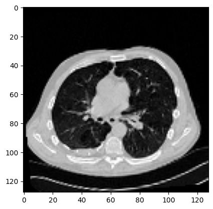

```python
import matplotlib.pyplot as plt

data = train_dataset.take(1)
images, labels = list(data)[0]
images = images.numpy()
image = images[0]
print("Dimension of the CT scan is:", image.shape)
plt.imshow(np.squeeze(image[:, :, 30]), cmap="gray")
```

Since a CT scan has many slices, let's visualize a montage of the slices.

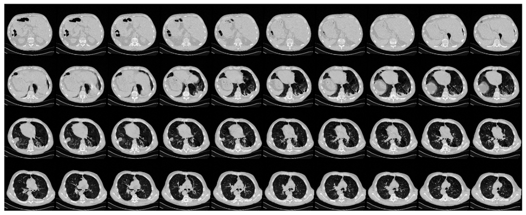

```python
def plot_slices(num_rows, num_columns, width, height, data):
    """Plot a montage of 20 CT slices"""
    data = np.rot90(np.array(data))
    data = np.transpose(data)
    data = np.reshape(data, (num_rows, num_columns, width, height))
    rows_data, columns_data = data.shape[0], data.shape[1]
    heights = [slc[0].shape[0] for slc in data]
    widths = [slc.shape[1] for slc in data[0]]
    fig_width = 12.0
    fig_height = fig_width * sum(heights) / sum(widths)
    f, axarr = plt.subplots(
        rows_data,
        columns_data,
        figsize=(fig_width, fig_height),
        gridspec_kw={"height_ratios": heights},
    )
    for i in range(rows_data):
        for j in range(columns_data):
            axarr[i, j].imshow(data[i][j], cmap="gray")
            axarr[i, j].axis("off")
    plt.subplots_adjust(wspace=0, hspace=0, left=0, right=1, bottom=0, top=1)
    plt.show()


# Visualize montage of slices.
# 4 rows and 10 columns for 100 slices of the CT scan.
plot_slices(4, 10, 128, 128, image[:, :, :40])
```

## GRIDSEARCH

Befor defining the model we need to find the best hyperparameters for our 3D CNN model. There're several methods for tunning these values, for this project we used Gridsearch.

### Tunning the CNN for batch size, dense layers and num of epochs 4 layers

```python
class MyHyperModel(kt.HyperModel):
    def build(self, hp):
        width=128
        height=128
        depth=64
        num_layers=4
        layer_configs = [
            {'filters': 64, 'kernel_size': 3, 'activation': 'relu', 'pool_size': 2},
            {'filters': 64, 'kernel_size': 3, 'activation': 'relu', 'pool_size': 2},
            {'filters': 128, 'kernel_size': 3, 'activation': 'relu', 'pool_size': 2},
            {'filters': 256, 'kernel_size': 3, 'activation': 'relu', 'pool_size': 2},
        ]
        inputs = keras.Input((width, height, depth, 1))
        x = inputs
        for i in range(num_layers):
            x = layers.Conv3D(filters=layer_configs[i]['filters'], kernel_size=layer_configs[i]['kernel_size'],
                              activation=layer_configs[i]['activation'])(x)
            x = layers.MaxPool3D(pool_size=layer_configs[i]['pool_size'])(x)
            x = layers.BatchNormalization()(x)
        x = layers.GlobalAveragePooling3D()(x)
        x = layers.Dense(hp.Choice('units', [256, 512]), activation="relu")(x)
        x = layers.Dropout(0.3)(x)
        outputs = layers.Dense(units=2, activation="sigmoid")(x)
        # Define the model.
        model = keras.Model(inputs, outputs, name="3dcnn")
        model.compile(loss='mse', optimizer='adam')
        return model

    def fit(self, hp, model, *args, **kwargs):
        return model.fit(
            *args,
            batch_size=hp.Choice("batch_size", [16, 32]),
            epochs=hp.Choice("epochs", [10, 20, 50, 100]),
            **kwargs,
        )
```

```python
MyHyperModel
```

```
__main__.MyHyperModel
```

```python
tuner = kt.GridSearch(
    hypermodel=MyHyperModel(),
    objective="val_loss",
    overwrite=True,
    directory="my_dir",
    project_name="tune_hypermodel",
)
tuner.search(
    train_dataset,
    validation_data=validation_dataset,
#     epochs=epochs,
    shuffle=True,
    verbose=2,
    callbacks=[checkpoint_cb],
)
```

```
Trial 16 Complete [00h 15m 17s]
val_loss: 0.020888980478048325

Best val_loss So Far: 0.0023479503579437733
Total elapsed time: 01h 50m 28s
INFO:tensorflow:Oracle triggered exit
```

```python
tuner.results_summary()
```

```
Results summary
Results in my_dir/tune_hypermodel
Showing 10 best trials
Objective(name="val_loss", direction="min")

Trial 0011 summary
Hyperparameters:
units: 512
batch_size: 16
epochs: 100
Score: 0.0023479503579437733

Trial 0002 summary
Hyperparameters:
units: 256
batch_size: 16
epochs: 50
Score: 0.009328976273536682

Trial 0007 summary
Hyperparameters:
units: 256
batch_size: 32
epochs: 100
Score: 0.018266554921865463

Trial 0003 summary
Hyperparameters:
units: 256
batch_size: 16
epochs: 100
Score: 0.018771272152662277

Trial 0015 summary
Hyperparameters:
units: 512
batch_size: 32
epochs: 100
Score: 0.020888980478048325

```

[output cut: 19 more lines]

```
Score: 0.07748047262430191

Trial 0014 summary
Hyperparameters:
units: 512
batch_size: 32
epochs: 50
Score: 0.11650165915489197

Trial 0005 summary
Hyperparameters:
units: 256
batch_size: 32
epochs: 20
Score: 0.13651446998119354
```

### Tunning the CNN for batch size, dense layers and num of epochs 2 layers

```python
class MyHyperModel(kt.HyperModel):
    def build(self, hp):
        width=128
        height=128
        depth=64
        num_layers=2
        layer_configs = [
            {'filters': 64, 'kernel_size': 3, 'activation': 'relu', 'pool_size': 2},
            {'filters': 64, 'kernel_size': 3, 'activation': 'relu', 'pool_size': 2},
        ]
        inputs = keras.Input((width, height, depth, 1))
        x = inputs
        for i in range(num_layers):
            x = layers.Conv3D(filters=layer_configs[i]['filters'], kernel_size=layer_configs[i]['kernel_size'],
                              activation=layer_configs[i]['activation'])(x)
            x = layers.MaxPool3D(pool_size=layer_configs[i]['pool_size'])(x)
            x = layers.BatchNormalization()(x)
        x = layers.GlobalAveragePooling3D()(x)
        x = layers.Dense(hp.Choice('units', [256, 512]), activation="relu")(x)
        x = layers.Dropout(0.3)(x)
        outputs = layers.Dense(units=2, activation="sigmoid")(x)
        # Define the model.
        model = keras.Model(inputs, outputs, name="3dcnn")
        model.compile(loss='mse', optimizer='adam')
        return model

    def fit(self, hp, model, *args, **kwargs):
        return model.fit(
            *args,
            batch_size=hp.Choice("batch_size", [16, 32]),
            epochs=hp.Choice("epochs", [50, 100]),
            **kwargs,
        )
```

```python
tuner = kt.GridSearch(
    hypermodel=MyHyperModel(),
    objective="val_loss",
    overwrite=True,
    directory="my_dir",
    project_name="tune_hypermodel",
)
tuner.search(
    train_dataset,
    validation_data=validation_dataset,
#     epochs=epochs,
    shuffle=True,
    verbose=2,
    callbacks=[checkpoint_cb],
)
```

```
Trial 8 Complete [00h 14m 28s]
val_loss: 0.025868674740195274

Best val_loss So Far: 0.0009386411402374506
Total elapsed time: 01h 27m 31s
INFO:tensorflow:Oracle triggered exit
```

```python
tuner.results_summary()
```

```
Results summary
Results in my_dir/tune_hypermodel
Showing 10 best trials
Objective(name="val_loss", direction="min")

Trial 0005 summary
Hyperparameters:
units: 512
batch_size: 16
epochs: 100
Score: 0.0009386411402374506

Trial 0006 summary
Hyperparameters:
units: 512
batch_size: 32
epochs: 50
Score: 0.002277660882100463

Trial 0001 summary
Hyperparameters:
units: 256
batch_size: 16
epochs: 100
Score: 0.006725195329636335

Trial 0007 summary
Hyperparameters:
units: 512
batch_size: 32
epochs: 100
Score: 0.025868674740195274

Trial 0002 summary
Hyperparameters:
units: 256
batch_size: 32
epochs: 50
Score: 0.03174979239702225

Trial 0003 summary
Hyperparameters:
units: 256
batch_size: 32
epochs: 100
Score: 0.05082961171865463

Trial 0000 summary
Hyperparameters:
units: 256
batch_size: 16
epochs: 50
Score: 0.09319579601287842

Trial 0004 summary
Hyperparameters:
units: 512
batch_size: 16
epochs: 50
Score: 0.09684352576732635
```

After finding these hyperparameters we are going to implement them within the models and try to achive the best accuracy.